# Laboration 1 Facit

Author

Isak Hietala

## Uppgift 1

I denna uppgift presenteras en utforskning av datamaterialet.

### i) Variabeltyper och skalor

| Variabel | Variabeltyp | Variabelskala |
| --- | --- | --- |
| investment_value | Kontinuerlig | Kvotskala |
| location_rating | Diskret | Intervallskala |
| construction_quality | Diskret | Intervallskala |
| rental_yield | Kontinuerlig | Kvotskala |
| maintenance_cost | Kontinuerlig | Kvotskala |
| property_type | Kvalitativ | Nominalskala |
| economic_conditions | Kvalitativ | Ordinalskala |

### ii) Parvisa samband

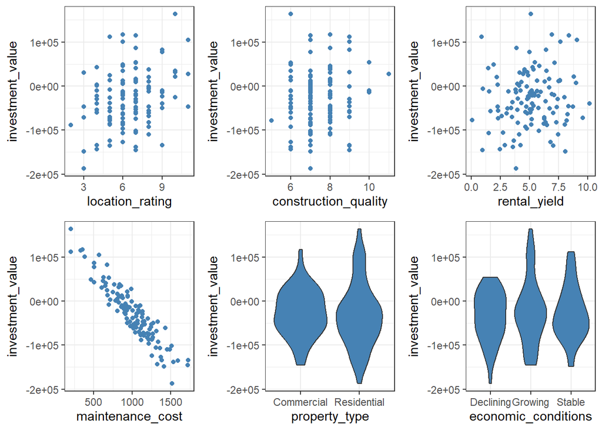

Tolkningen av spridningsdiagram (diagram 1-4) bör beröra följande punkter:

- Är det ett linjär eller icke-linjärt samband?
  - Är förändringen av y konstant och monotont (samma riktning) kan sambandet anses linjärt.
- Är sambandet positivt eller negativt?
  - Ökar y när x ökar är det positivt samband.
- Är sambandet starkt eller svagt?
  - Punkter som ligger tätt intill varandra anses ha ett starkt samband.
- Förekommer extremvärden?
  - Finns det någon punkt som ligger långt bort från den övriga punktsvärmen.

Tolkningen av fioldiagrammen (eller annan diagramtyp som visar **fördelningen** av y utefter kategorierna på x) bör beröra följande punkter:

- Skiljer sig lägesmåtten mellan kategorierna?
- Skiljer sig fördelningens form mellan kategorierna?

### iii) Motivering av variabler

Variabler som i ii) ansågs ha ett icke-svagt samband med y eller att lägesmåtten skiljer sig åt mellan kategorierna bör inkluderas i modellen.

Linjära samband inkluderas med enskilda lutningsparametrar ($\beta_j \cdot X_j$) medan kvalitativa variabler inkluderas med en transformering till $k-1$ indikatorvariabler där $k$ beskriver antalet kategorier.

## b)

Utgår från en modell som innehåller alla variabler. Den enskilda rapporten kan innehålla andra modellstrukturer givet svaret i a.iii).

### i)

| Variabel | Skattning | Medelfel | t-värde | p-värde |
| --- | --- | --- | --- | --- |
| (Intercept) | 58231.843 | 4446.661 | 13.096 | 0 |
| location_rating | 9914.222 | 250.892 | 39.516 | 0 |
| construction_quality | 5190.500 | 454.344 | 11.424 | 0 |
| rental_yield | 1950.579 | 230.903 | 8.448 | 0 |
| maintenance_cost | -199.723 | 1.566 | -127.534 | 0 |
| property_typeResidential | -19738.228 | 969.078 | -20.368 | 0 |
| economic_conditionsGrowing | 20521.962 | 1171.036 | 17.525 | 0 |
| economic_conditionsStable | 11475.892 | 1132.144 | 10.136 | 0 |

Avrundade värden presenteras för enklare läsning av tabellen.

Byt ut ord inuti [] med aktuella namn och enheter för respektive variabel. En ökning av responsvariabeln sker om parameterskattningen är positiv, minskning om den är negativ. Se variabelbeskrivningen i LISAM för enheter.

Alla *kvantitativa* variabler ska tolkas enligt följande.

- När [förklarande variabeln] ökar med en [enhet], [ökar/minskar] [responsvariabeln] med [koefficientvärde] givet att alla andra variabler hålls konstant.

Alla *kvalitativa* variabler ska tolkas enligt följande.

- När observationen antar värdet [kategori], [ökar/minskar] [responsvariabeln] med [koefficientvärde] jämfört med [referenskategori] givet att alla andra variabler hålls konstanta.

### ii)

Ett 95% konfidensintervall utgår från koefficienttabellens skattade värde och medelfel. Tabellvärdet ($t_{n-(k+1); 0.975}$) kan räknas ut genom att räkna antalet observationer - antalet rader i koefficienttabellen.

$$9914.222 \pm 1.981 \cdot 250.892$$

$$1.1475892\times 10^{4} \pm 1.981 \cdot 1132.144$$
Tolkningen av respektive intervall bör involvera:

Med 95% säkerhet täcker det givna intervallet den sanna effekt som [förklarande variabel] har med [responsvariabeln].

### iii)

|  | Df | Sum Sq | Mean Sq | F value | Pr(>F) |
| --- | --- | --- | --- | --- | --- |
| location_rating | 1 | 46358957547 | 46358957547 | 1806.096 | 0 |
| construction_quality | 1 | 3525682110 | 3525682110 | 137.357 | 0 |
| rental_yield | 1 | 9603995183 | 9603995183 | 374.162 | 0 |
| maintenance_cost | 1 | 408032589101 | 408032589101 | 15896.519 | 0 |
| property_type | 1 | 7001233250 | 7001233250 | 272.761 | 0 |
| economic_conditions | 2 | 8000741491 | 4000370745 | 155.850 | 0 |
| Residuals | 112 | 2874821274 | 25668047 | NA | NA |

Ett F-test för hela modellen undersöker alla lutningsparametrar samtidigt.

$$\begin{aligned}
H_0&: \beta_1=\beta_2=\beta_3=\beta_4=\beta_5=\beta_6=\beta_7 = 0\\
H_a&: \text{Minst en av } \beta_j \text{ i } H_0 \text{ är skild från 0}
\end{aligned}$$
Testvariabeln beräknas som $MSR / MSE$ vilket innebär att summan av de sekventiella kvadratsummorna behöver beräknas. MSE kan tas direkt från ANOVA-tabellen.

$$\begin{aligned}
SSR = 4.64 \times 10^{
10
}+3.53 \times 10^{
9
}+9.6 \times 10^{
9
}+4.08 \times 10^{
11
}+7 \times 10^{
9
}+8 \times 10^{
9
} = 4.825232\times 10^{11}
\end{aligned}$$
$$\begin{aligned}
F_{test} = \frac{SSR / k}{SSE / (n - (k+1))} = \frac{4.825232\times 10^{11} / 7}{2.5668047\times 10^{7}} = \frac{6.8931886\times 10^{10}}{2.5668047\times 10^{7}} \approx 2685.513
\end{aligned}$$

Kritiska värdet tas från F-fördelningen med $k$ respektive $n - (k+1)$ frihetsgrader. Nedan beräknas med 5 procents signifikans.

$$\begin{aligned}
F_{krit} = F_{k; n - (k+1); 0.05} = F_{7; 112; 0.05} = 2.092
\end{aligned}$$

Om $F_{test}$ är större än $F_{krit}$ så kan $H_0$ förkastas och vi har på fem procents signifikans bevis för att minst en lutningsparameter är skild från 0.

### iv)

Att undersöka om en delmängd av variablerna kan tas bort från modellen innebär ett partiellt F-test. I $H_0$ ska alla lutningsparametrar som hör till de kvalitativa variablernas indikatorvariabler inkluderas.

- Om modellen i b.i) innehåller båda kvalitativa variablerna bör detta test undersöka om de kan tas bort.
- Om modellen i b.i) innehåller endast en kvalitativ variabel bör detta test undersöka om endast den kan tas bort.
- Om modellen i b.i) innehåller inga kvalitativa variabler bör detta test undersöka ifall det var rätt beslut att inte inkludera dem.

$$\begin{aligned}
H_0&: \beta_5=\beta_6=\beta_7 = 0\\
H_a&: \text{Minst en av } \beta_j \text{ i } H_0 \text{ är skild från 0}
\end{aligned}$$
Testvariabeln justeras nu för att endast ta hänsyn till SSR från de variabler som inkluderas i $H_0$ och $s$ betecknar hur många lutningsparametrar som undersöks.

Med hjälp av de sekventiella kvadratsummorna kan $SSR(kvalitativa|kvantativa)$ beräknas direkt från ANOVA-tabellen eftersom de kvalitativa variablerna läggs till sist i modellen.

$$\begin{aligned}
SSR(kvalitativa|kvantitativa) = 7 \times 10^{
9
}+8 \times 10^{
9
} = 1.5001975\times 10^{10}
\end{aligned}$$

$$\begin{aligned}
F_{test} =
\frac{SSR(kvalitativ|kvantitativ) / s}{SSE / (n - (k+1))} =
\frac{1.5001975\times 10^{10} / 3}
{2.5668047\times 10^{7}} =
\frac{5.0006582\times 10^{9}}
{2.5668047\times 10^{7}} \approx
194.82
\end{aligned}$$
Det kritiska värdet tas från F-fördelningen med $s$ respektive $n - (k+1)$ frihetsgrader. Nedan beräknas med 5 procents signifikans.

$$\begin{aligned}
F_{krit} = F_{s; n - (k+1); 0.05} = F_{3; 112; 0.05} = 2.686
\end{aligned}$$
Om $F_{test}$ är större än $F_{krit}$ så kan $H_0$ förkastas och vi har på fem procents signifikans bevis för att minst en lutningsparameter är skild från 0 och variablerna kan inte tas bort samtidigt.

Om $F_{test}$ **inte** är större än $F_{krit}$ så kan $H_0$ **inte** förkastas och vi har på fem procents signifikans inte hittat bevis för att minst en lutningsparameter är skild från 0. Den praktiska tillämpningen blir att vi kan anse att variablerna kan plockas bort från modellen.

## c)

Med hjälp av funktionen `residualPlots()` från kapitel 4.1.4 i Statistisk teori och tillämpningar i R kan följande residualdiagram skapas från den reviderade modellen. Om b.iv) ansett att ytterligare variabler kan plockas bort från modellen bör modellen anpassas om utan dessa.

### i)

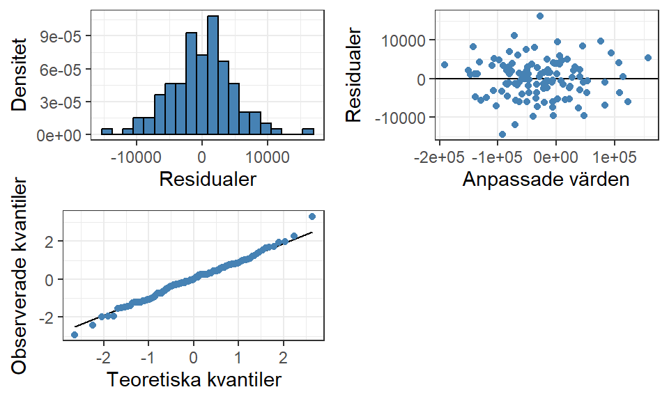

Residualdiagram för den anpassade modellen

Antaganden som råder kan sammanfattas till $E \sim N(0, \sigma^2)$.

Diagrammen ska undersökas avseende följande punkter:

- Är residualerna normalfördelade?
  - Detta undersöks genom histogrammet och kvantildiagrammet. Histogrammet ska uppvisa en symmetrisk klockliknande form centrerad kring 0. Kvantildiagrammets punkter ska följa den teoretiska linjen.
- Har residualerna lika varians?
  - Detta undersöks i spridningsdiagrammet där vi vill att punkterna ska kunna täckas av två parallella linjer som ett lock och en botten.
- Är sambandet linjärt?
  - Detta undersöks i kvantildiagrammet och spridningsdiagrammet. Vi vill inte se något icke-linjärt mönster i punkterna, t.ex. att punkterna först ökar och sedan minskar.
- Är residualerna oberoende?
  - Detta undersöks främst genom ett resonemang kring datainsamlingen. Nu har ingen tydlig information om hur datainsamlingen faktiskt samlats in presenterats i instruktionerna men man kan anta att det är slumpmässiga urval som innebär oberoende.

En modell som inte uppfyller antaganden har starka avvikelser från det önskade mönstret i minst ett av diagrammen.

### ii)

I residualdiagrammen kan det finnas observationer som ligger långt bort från de övriga, t.ex. i histogrammets svansar, kvantildiagrammets ytterkanter eller nära ritytans kanter i spridningsdiagrammet.

Om extremvärden identifierats bör rapporten innehålla en hänvisning till diagram i a) för att identifiera vilken observation och för vilken variabel som den anses vara ett extremvärde.

## d)

Ett enkelt utvärderingsmått som kan beräknas är $R^2 = \frac{SSR}{SSY} = 1 - \frac{SSE}{SSY}$ som för den fullständiga modellen blir:

$$\begin{aligned}
R^2 = 1 - \frac{2.8748213\times 10^{9}}{4.8539802\times 10^{11}} = 0.994
\end{aligned}$$

### En bra modell

Om förklaringsgraden är större än 50% kan modellen anses relativt bra då måttet beskriver andelen av den totala variationen som modellen beskriver.

Modellen måste också uppfylla modellantaganden för att den ska anses vara bra.

### En dålig modell

En förklaringsgrad på 50% eller mindre kan anses vara dålig då modellen endast beskriver en minoritet av den totala variationen.

Om modellen inte uppfyller antaganden kan modellen inte anses bra och då bör rapporten inkludera någon motivering av vad för fenomen som residualdiagrammen visar (vilket antagande som specifikt inte är uppfyllt) och hur vi skulle kunna gå tillväga för att förbättra modellen.